# A workshop on: MATHEMATICAL ENGINEERING OF DEEP LEARNING - FOUNDATIONs

Sequence models

Presented by Benoit Liquet

University Of Pau et Pays de L’Adour

- Based on **Chapter 7** of the book [Mathematical Engineering of Deep Learning](https://deeplearningmath.org/) by Benoit Liquet, Sarat Moka and Yoni Nazarathy
- Data are available at https://github.com/benoit-liquet/IASC-DL

# Contents

- Sequence data and Activities
- Recurrent Neural Network (RNN)
- Long Short Term Memory (LSTM)
- Gated Recurrent Unit Models
- Transformers
- Example: Usage of auto-encoders for language translation

## Overview of Sequence Data

### Forms of Sequence Data

- Analysis of sequential data: text sentences, time-series, and other discrete sequences such as DNA.
- Design to handle sequential information while Convolutional Neural Network process spatial information.
- Key point: data carry some dependency due to the sequential order of the data.
- **Sequence Models** is very popular:
  - speech recognition
  - voice recognition
  - time series prediction
  - natural language processing.

### Notations

- An input data sequence denoted via $x = \big(x^{<1>},\ldots, x^{<T>}\big)$,
- the superscripts $<t>$ indicate ``time’’ or order in the sequence,
- Each $x^{<t>}$ is a p-dimensional numerical data point (or vector).
- The number of elements, $T$, is sometimes fixed, but is also often not fixed and can be essentially unbounded.
- A classical example: univariate data sequences ($p=1$) arising in time-series of economic, natural, or weather data. Similarly, multivariate time-series data ($p>1$ but typically not huge) also arise in similar settings.

## Tasks Involving Sequence Data

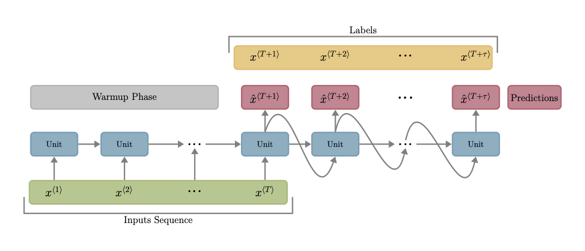

- (a) is lookahead prediction which in the application context of text implies predicting the next word (or collection of words) in a sequence.

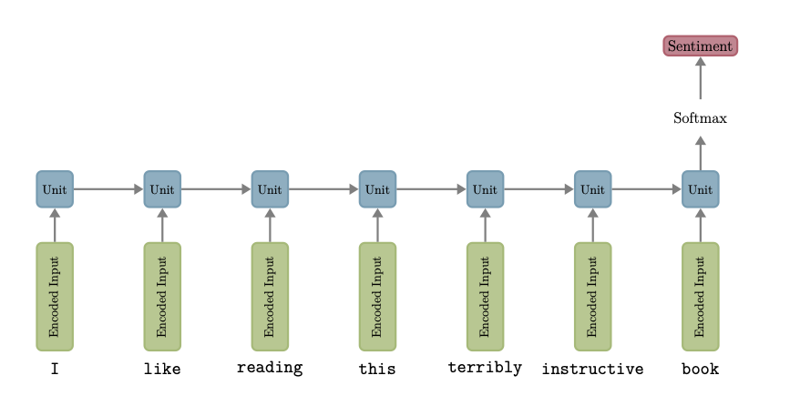

- (b) is sequence regression or classification which can be used for applications such as sentiment analysis.

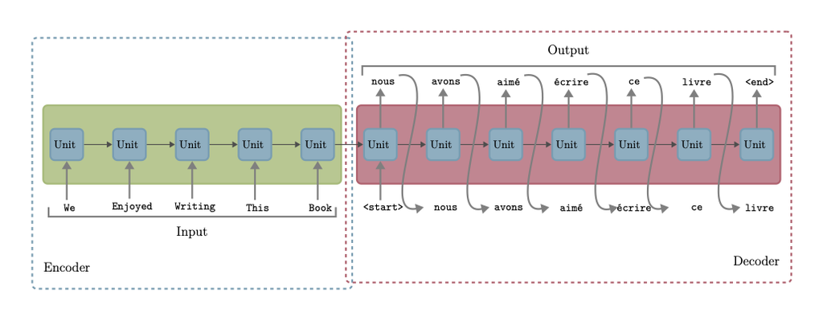

- 3. translates the input sequence from one embedding into another. This is most common in the application of machine translation (e.g. Hebrew to Arabic).

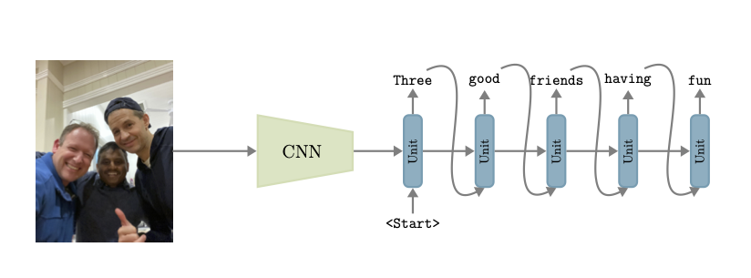

- (d) involves decoding an input into a sequence. One example application is image captioning where text is generated to describe the image.

Let precise some input and output in each cases:

- (a), lookahead. In the context of text is to predict the next word based on the sequence of input words.
  - The output is the sequence of inputs shifted by one and the model attempts to predict the next word (or next few words) at any time $t$.
  - In the context of time-series: **autoregressive** analysis. After a warmup phase, the model predicts the next value in the time series
  - For an input sequence $x = \big(x^{<1>}, \ldots,x^{<t>}\big)$ we have a future prediction $\hat{y} = (\hat{y}^{<t+1>}, \ldots, \hat{y}^{<t+\tau>}\big)$ for some **time horizon** $\tau$.
- (b), In sentiment analysis where the sentiment or *general vibe* of a sentence is determined. This output may be a vector of probabilities over possible classes, e.g. ${``happy", ``sad", ``indifferent"}$, and in such a case the output is amenable to classification.
  - $\hat{y}$ is a vector of probabilities and can be converted to a categorical output.
- (c), machine translation where the input sentence is from one language and the output sentence is from another language.
  - Composed of two RNNs in an **encoder decoder architecture**.
  - Observe that with this task the input $x$ is a sequence of a certain length while the output $\hat{y}$ is a sequence of a potentially different length.
- (d), image captioning. Here for an input image, we wish to output a sentence describing the image.
  - a **convolutional neural network** creating a features vector in a latent space.
  - This output is then fed into an RNN which acts as a decoder
  - $x$ is an image, and $\hat{y}$ represents an output sentence.

## Text Data

- Context of textual data $t$ is typically not the time of the text but rather the index of the word or token
- **Natural Language Processing** (NLP) use **tokenizers** which break up text into natural ``words’’ or parts of words known as **tokens**

```r
# Load the tokenizers package
library(tokenizers)

# Define a string to be tokenized
text <- "This is an example sentence."

# Use the word_tokenizer to split the string into individual tokens
tokens <- tokenize_words(text)

# Print the tokens
print(tokens)
```

```
[[1]]
[1] "this"     "is"       "an"       "example"  "sentence"
```

### Convert Text Data to numerical format

- **One-hot encoding** for converting text data into numerical format
- **on one-hot encoding**, each word in the text is represented by a binary vector where all elements are zero except for one element, which is set to one.
- The **length of the binary vector** is equal to the total number of unique words in the text.

```r
library(text2vec)
# Define a list of strings to be encoded
texts <- c("This is an example sentence.", "Another example sentence.")

# Tokenize the text into individual words
tokens <- unlist(strsplit(texts, split = " "))

# Create a vocabulary from the tokens
vocab <- unique(tokens)
vocab
```

```
[1] "This"      "is"        "an"        "example"   "sentence." "Another"
```

```r
# Create a one-hot encoding vector for each word in the vocabulary
result <- matrix(0, ncol = length(vocab), nrow = length(tokens))
for (i in 1:length(vocab)) {
  result[, i] <- as.integer(tokens == vocab[i])
}
colnames(result) <- vocab
rownames(result) <- tokens
# Print the one-hot encoding matrix
print(result)
```

```
          This is an example sentence. Another
This         1  0  0       0         0       0
is           0  1  0       0         0       0
an           0  0  1       0         0       0
example      0  0  0       1         0       0
sentence.    0  0  0       0         1       0
Another      0  0  0       0         0       1
example      0  0  0       1         0       0
sentence.    0  0  0       0         1       0
```

- **Drawback**:
  - One-hot encoding can result in a high-dimensional feature space, which can make it computationally infeasible to work with large datasets.
  - One-hot encoding **does not capture the semantic similarity between words**.

## Word embedding

- **Word embedding** is a technique used to represent words as numerical vectors in a high-dimensional space, typically 50-300 dimensions.
- The goal of word embedding is to capture the semantic meaning of words and their relationships with other words in the language.
- Word embedding is usually created by training a neural network on a large corpus of text, where each word is represented as a one-hot encoded vector.
- The neural network learns to map each one-hot encoded vector to a dense vector representation that captures the meaning of the word.
- One popular algorithm for creating word embeddings is Word2Vec, which uses a shallow neural network to learn word representations based on their context in the text.
- Another popular algorithm for creating word embeddings is GloVe, which uses a matrix factorization approach to learn word representations based on the co-occurrence statistics of words in the text.
- **Word embedding** can be visualized using techniques such as t-SNE or PCA to reduce the dimensionality of the vectors and plot them in two or three dimensions.

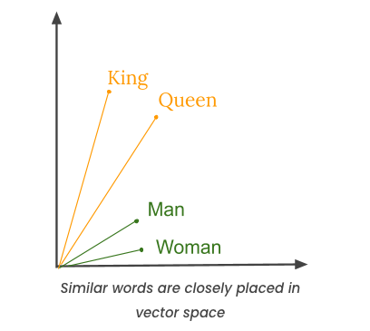

- **Word embedding** has revolutionized natural language processing and has led to significant improvements in many NLP tasks.
- **GloVe** avaivalble at https://github.com/stanfordnlp/GloVe
- You can download a zip file called *glove.6B.zip* having 100-dimensional embedding vectors for 400,000 words.

```r
## Glove available here
##https://nlp.stanford.edu/projects/glove/
glove_dir = "PRACTICE/glove.6B/"
lines <- readLines(file.path(glove_dir, "glove.6B.100d.txt"))

words <- NULL

embeddings_index <- new.env(hash = TRUE, parent = emptyenv())
for (i in 1:5000) {
  line <- lines[[i]]
  values <- strsplit(line, " ")[[1]]
  word <- values[[1]]
  embeddings_index[[word]] <- as.double(values[-1])
  words[i] <- word
}

cosine_sim <- function(u, v){
  num = sum(u * v)
  norm_u = sqrt(sum(u*u))
  norm_v = sqrt(sum(v*v))
  den = norm_u * norm_v
  cos_sim <- num/den
  return(cos_sim)
}


e_king <- as.numeric(embeddings_index[["king"]])
e_queen <- as.numeric(embeddings_index[["queen"]])
e_beach <- as.numeric(embeddings_index[["beach"]])
cat("cosine similarity(king, queen)", cosine_sim(e_king, e_queen))
```

```
cosine similarity(king, queen) 0.7507691
```

```r
cat("cosine similarity(king, beach)", cosine_sim(e_king, e_beach))
```

```
cosine similarity(king, beach) 0.2237459
```

## RNN architecture is task specific

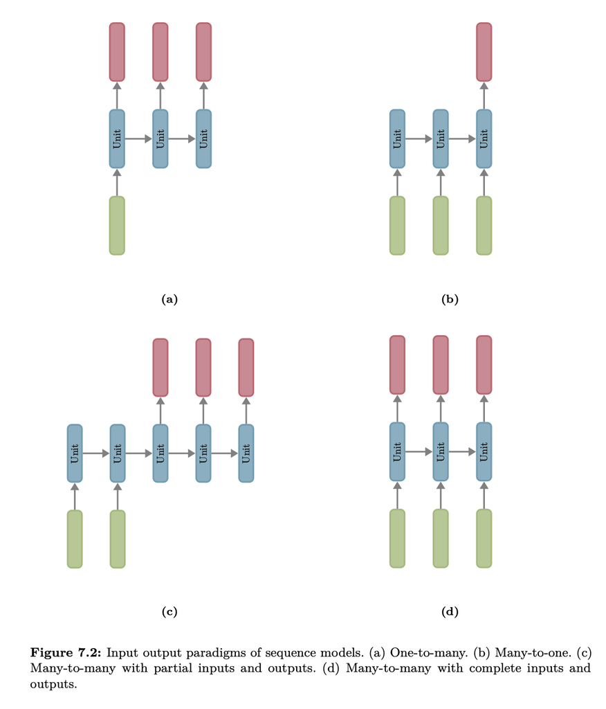

## Basic Recurrent Neural Networks

- RNN have the abilitiy to:
  - deal with variable-length sequences,
  - maintain sequence order
  - keep track of long-term dependencies
  - to share parameters across an input sequence.

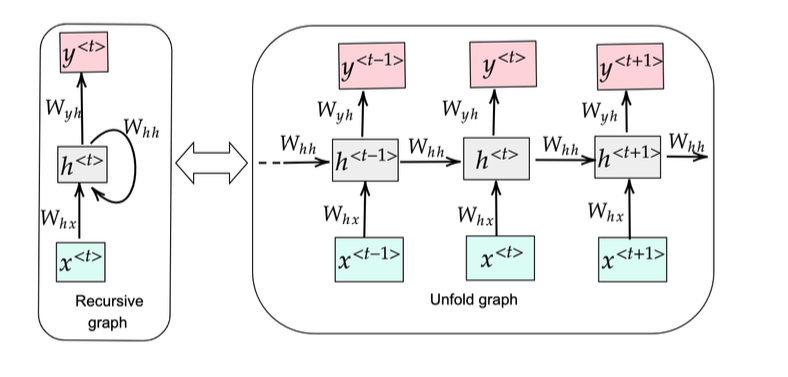

- RNN introduces an internal loop which allows information to be passed from one step of the network to the next.

- RNN maintains a hidden state, also termed cell state, which allows the model to keep memory as an input sequence is processed.
- The state evolution can be represented via the recurrence relation,

$$\underbrace{h^{<t>}}_{\textrm{current state}} = f_{\theta_{hx},
\theta_{hh}} (\underbrace{h^{<t-1>}}_{\textrm{old
state}}, \underbrace{x^{<t>}}_{\textrm{input vector}}),$$

acting on the sequence of input data $x = \big( x^{<1>}, x^{<2>},\ldots\big)$, to create a sequence of cell states $\big(h^{<1>}, h^{<2>}, \ldots \big)$, where the initial state $h^{<0>}$ is typically taken as a zero vector

- At every time step $t$ the same function $f_{\theta_{hx}, \theta_{hh}}(\cdot)$ is used with the same fixed (over time) sets of parameters $\theta_{hx}$ and $\theta_{hh}$.
- The output sequence $\hat{y} = \big( \hat{y}^{<1>}, \hat{y}^{<2>}, \dots \big)$ is defined at each time step by an another function, $g_{\theta_{yh}}(\cdot)$ with,

$$\hat{y}^{<t>}=g_{\theta_{yh}}(h^{<t>}),$$

The recursive loop enables us to express the cell state at time t, $h^{<t>}$, in terms of the $t$ first inputs, namely, omitting the parameter subscripts from $f_{\theta_{hx}, \theta_{hh}}(\cdot)$, we have,

$$h^{<t>}=f(\overbrace{\ldots
\underbrace{f(\overbrace{f(\underbrace{f(h^{<0>},x^{<1>})}_{h^{<1>}},x^{<2>})}^{h^{<2>}},x^{<3>})}_{h^{<3>}}\ldots}^{h^{<t-1>}},x^{<t>}).$$

Thus, since at time $t$, the output $\hat{y}^{<t>}$ is a function of $h^{<t>}$, we can also express the output as a function of the inputs up until time step $t$. Namely,

$$\hat{y}^{<t>}=g_{\theta}^{(t)}
(x^{<1>},x^{<2>},x^{<3>},\ldots,x^{<t>})$$

- Specifically,

$$\begin{equation}
\label{eq:rnn-full-gate}
\left\{
\begin{aligned}
h^{<t>} &= S_h(W_{hh} h^{<t-1>} + W_{hx}
x^{<t>}+b_h)\\
{\hat{y}}^{<t>} &= S_y(W_{yh} h^{<t>}+b_y).
\end{aligned}\right.
\end{equation}$$

- The parameters, $\theta = (\theta_{hx}, \theta_{hh}, \theta_{yh})$ are captured via weight matrices and bias vectors.
- $S_h(\cdot)$ and $S_y(\cdot)$ are vector activation functions,
- We denote the dimension of $x^{<t>}$ as $p$, the dimension of $y^{<t>}$ as $q$, and the dimension of the cell state of $h^{<t>}$ as $m$.
- Hence $W_{hx} \in \Re^{m \times p}$, $W_{hh} \in \Re^{m \times m}$, $W_{yh} \in \Re^{q \times m}$, $b_h \in \Re^m$, and $b_y \in \Re^q$.
- One variant is to feed the output of the previous time step, ${\hat{y}}^{{\langle t-1 \rangle}}$, into the input so that the input at every time is not $x^{{\langle t \rangle}}$ but rather some merging of $x^{{\langle t \rangle}}$ and ${\hat{y}}^{{\langle t-1 \rangle}}$.

$$\begin{equation}
\left\{
\begin{aligned}
h^{{\langle t \rangle}} &= S_h(W_{hh} h^{{\langle t-1 \rangle}} +
W_{hx}(x^{{\langle t \rangle}} + {\mathcal T}\big( \hat{y}^{{\langle t-1
\rangle}} \big) ) +b_h)\\
{\hat{y}}^{{\langle t \rangle}} &= S_y(W_{yh} h^{{\langle t
\rangle}}+b_y),
\end{aligned}\right.
\end{equation}$$

where ${\mathcal T}\big(\cdot\big)$ is an abstraction of some transformation which results in a vector of dimension $p$ (like $x^{{\langle t \rangle}}$).

### A RNN unit through its computational graph

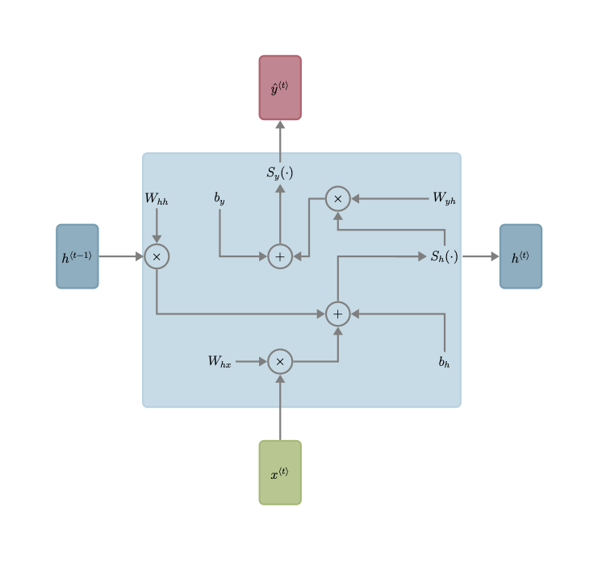

This simple structure of cell could achieve different tasks such as predict short sentence such as predicting the next word of The reading of this book is

### A Simple Concrete Toy Example

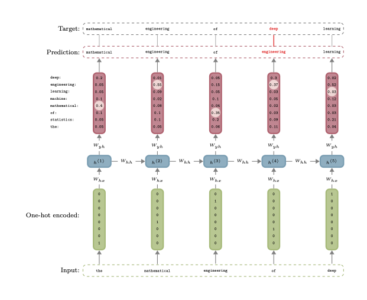

In our toy example assume a lexicon with $p=8$ words, appearing here in lowercase alphabetical order as,

$$\Big[\textrm{deep},\textrm{engineering},\texttt{learning},
\textrm{machine},\textrm{mathematical},\textrm{of}, \textrm{statistics},
\textrm{the}\Big]$$

where each word is represented by a vector in $\Re^8$. So for example the text,

$$\textrm{"the mathematical engineering of deep learning"},$$

## Training an RNN

$$\begin{equation}
\label{eq:general-rnn-outer-cost}
C(\theta)= \dfrac{1}{T} \sum_{t=1}^{T} C^{<t>}(\theta).
\end{equation}$$

Here $C^{<t>}(\theta)$ denotes the individual loss associated with time $t$. For example, continuing with the text language model from above, we may set,

$$\begin{equation}
\label{eq:cat-ent-text}
C^{<t>}(\theta) = - \sum_{k=1}^q y^{<t>}_k \log
\hat{y}^{<t>}_k,
\end{equation}$$

- keep in mind that ${y}^{<t>}$ is one-hot encoded and hence the summation has a single non-zero summand.
- Further, note that even if word embeddings are used for the input $x^{<t>}$, then the output $\hat{y}^{<t>}$ still represents a probability vector over the lexicon of size $q$ so that it is comparable to the target output $y^{<t>}$.

### Backpropagation Through Time

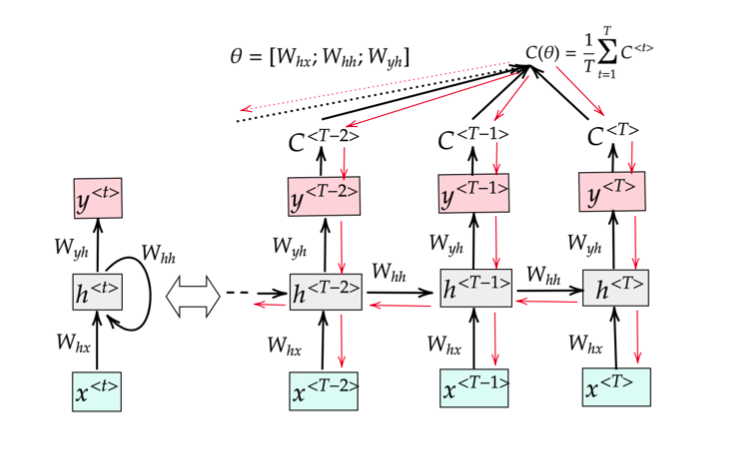

- Gradient computation of $C(\theta)$ with respect to the various weight matrices and bias vectors in $\theta$ is somewhat similar to the backpropagation algorithm
- However, a key difference lies in the fact that the same weight and bias parameters are used for all time $t$
- This difference as well as the fact that inputs to RNN are of arbitrary size $T$.
- see chapter 7 of our book for more details:
  $$\zeta^{<t>} = \frac{\partial C(\theta) }{\partial h^{<t>}}.$$
- The essence of backpropagation is computing $\zeta^{<t-1>}$ based on $\zeta^{<t>}$.

$$\begin{equation}
\label{eq:adjoint-back-prop-through-time}
\zeta^{<t>} =
\begin{cases}
\frac{1}{T}\sum_{\tau=1}^T \dot{C}^{<\tau>}(h^{<\tau>}),
& t = T,\\[5pt]
\frac{\partial h^{<t+1>}}{\partial h^{<t>}} \,
\zeta^{<t+1>},
& t = T-1,\ldots,1,
\end{cases}
\end{equation}$$

- For simplicity let us focus only on $W_{hh}$, denoted here as $W$ for brevity. Specifically, we are interested in evaluating the $m \times m$ derivative matrix,

$$\begin{equation}
\label{eq:rnn-g-w}
g_W = \frac{\partial C}{\partial W}
= \frac{1}{T} \sum_{t=1}^T \frac{\partial C^{{\langle t \rangle}}\big(
h^{{\langle t \rangle}}, y^{{\langle t \rangle}} \, ; \,
W\big)}{\partial W},
\end{equation}$$

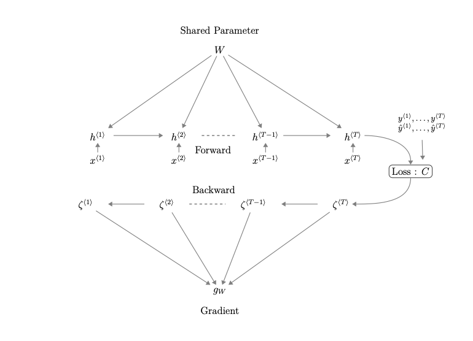

- Using the computational graph and the multi-variate chain rule we arrive at,

$$\begin{equation}
\label{eq:rough-g-w-sum-comps}
g_W
= \frac{1}{T} \sum_{t=1}^T
\sum_{\tau =1}^t
\sum_{j=1}^m \frac{\partial h_j^{<\tau>}}{\partial W}
\zeta_j^{<\tau>},
\end{equation}$$

### Computational Challenges

In RNN we get for $t=1,\ldots,T-1$,

$$\zeta^{<t>} =
\frac{\partial h^{<t+1>}}{\partial h^{<t>}}
\frac{\partial h^{<t+2>}}{\partial h^{<t+1>}}
\cdot \quad
\ldots
\quad \cdot
\frac{\partial h^{<T-1>}}{\partial h^{<T-2>}}
\frac{\partial h^{<T>}}{\partial h^{<T-1>}}
\zeta^{<T>}.$$

Now ignoring the action of the activation function (treating it is an identity function), ignoring the input $x^{<t>}$, and ignoring the bias term, we obtain,

$$\begin{equation}
\label{eq:rnn-zeta-rec}
\zeta^{<t>} =
\Big(W_{hh}^{\top}\Big)^{T-t}
\zeta^{<T>}.
\end{equation}$$

- The weight matrices of all unrolled layers are the same
- Hence, in recurrent neural networks trained on inputs with large sizes $T$, it is very likely that during backpropagation, the adjoint values $\zeta^{<t>}$ vanish or explode.
- This follows from the matrix power, since in most situations, the **maximal eigenvalue** of $W_{hh}$ is likely to not be at or near unity.
- If $T$ is large then for $t < T_0$ where $T_0$ is some value less than $T$, we will have that $\zeta^{<t>} \approx 0$.
- For example if $T=300$, we may have $T_0=250$:
  $$g_W
  \approx \frac{1}{T} \sum_{t=T_0}^T
  \sum_{\tau =T_0}^t
  \sum_{j=1}^m \frac{\partial h_j^{<\tau>}}{\partial W}
  \zeta_j^{<\tau>}.$$
- we see that the gradient is only updated based on near effects, and not based on long-term effects since inputs to the sequence $x^{<t>}$ for $t < T_0$ do not play a role.
- For example in language modelling, the contribution of faraway words to predicting the next word at time-step diminishes when the gradient vanishes early on.

As an example consider the text *“Slava grew up in Ukraine before he moved around the world, first to the United States, and then to Australia. He loves teaching languages and is an avid teacher of his own mother tongue …*”. In this case, completion of the end of the text, marked via *…*, requires information from the start of the text.

- With recurrent neural networks, computation of the loss and of the gradients across an entire corpus is generally infeasible or too expensive. In practice, a batch of sentences is used to compute the loss to limit the sequence size $T$.
- Note also that in cases where $W_{hh}^\top$ has eigenvalues greater than unity in absolute value an exploding gradient phenomena is likely to occur. For this, gradient clipping may be employed, which is technique that scales down the gradient before applying an update when the norm of the gradient is greater than some threshold.
- Another technique is to use truncated backpropagation through time (TBPTT) which limits the number of time steps the signal can backpropagate in each forward pass.

## A short practice

- R: tutorial 2, IMBd data
- [Python: tutorial 2, IMBd data](https://colab.research.google.com/drive/1R_T_klRPjp0x2k715zVcxGbXBPbGz9cx?usp=sharing)

## Generalizations and Modifications to RNNs

- Bidirectional recurrent neural network

$$\begin{equation}
\label{eq:rnn-full-gate-reverse}
\left\{
\begin{aligned}
h_f^{<t>} &= S_h(W_{hh}^f h_f^{<t-1>} + W_{hx}^f
x^{<t>}+b_h^f)\\
h_r^{<t>} &= S_h(W_{hh}^r h_r^{<t+1>} + W_{hx}^r
x^{<t>}+b_h^r)\\
{\hat{y}}^{<t>} &= S_y(W_{yh}^f h_f^{<t>} + W_{yh}^r
h_r^{<t>}+b_y)
\end{aligned}\right. ,
\end{equation}$$

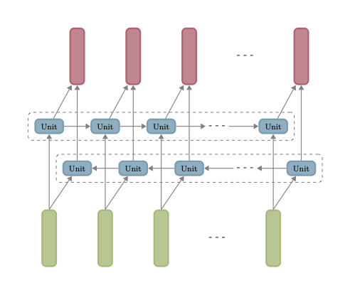

- Such bidirectional data flow enables the model to be more versatile, especially for cases where the **entire input sequence** is available and such as **handwritten text recognition**, **machine translation**, **speech recognition**, and **part-of-speech tagging**, among other applications.

### Stacked recurrent neural network

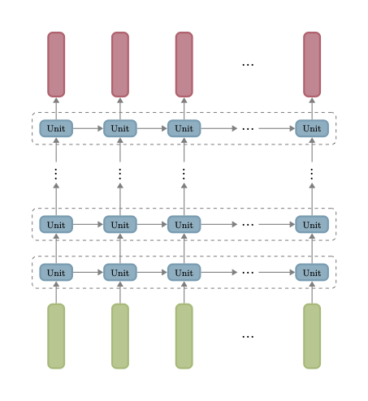

$$\begin{equation}
\label{eq:rnn-full-gate-deeper}
\left\{
\begin{aligned}
h_{[1]}^{<t>} &= S_h^{[1]}(W_{hh}^{[1]} h^{<t-1>}_{[1]}
+ W_{hx}^{[1]} x^{<t>}+b_h^{[1]})\\
h_{[2]}^{<t>} &= S_h^{[2]}(W_{hh}^{[2]} h^{<t-1>}_{[2]}
+ W_{hx}^{[2]} h^{<t>}_{[1]}+b_h^{[2]})\\
&\vdots\\
h_{[L]}^{<t>} &= S_h^{[L]}(W_{hh}^{[L]} h^{<t-1>}_{[L]}
+ W_{hx}^{[L]} h^{<t>}_{[L-1]}+b_h^{[L]})\\
{\hat{y}}^{<t>} &= S_y(W_{yh} h^{<t>}_{[L]}+b_y)
\end{aligned}\right. ,
\end{equation}$$

- where we now use notation such as $[1],\ldots,[L]$ to signify the depth of individual components and $L$ is the number of stacked layers.
- Such stacked RNN models are clearly more expressive and thus they generally outperform single-layer recurrent neural networks when trained with enough data.
- However, they are harder to train as the number of parameters clearly grows proportionally to the number of layers.

# Long Short Term Memory Models

Long Short Term Memory Models (LSTM) are generalizations of basic recurrent neural networks that are designed to preserve information over many time steps.

- A key concept in LSTM is to extend the hidden units of RNNs by separating the information flow between units into two groups where one group is called the cell state and denoted $c^{<t>}$, while the other group is called the hidden state and denoted $h^{<t>}$.
- long term dependancies are generally retained through $c^{<t>}$
- short term dependencies are carried by $h^{<t>}$.
- The interaction between these groups of neurons is enabled via additional groups of neurons called internal gates which are generally vectors with entries in $[0,1]$, denoted $g_f^{<t>}$, $g_i^{<t>}$, and $g_o^{<t>}$.
- An additional internal group of neurons, denoted via $\tilde{c}^{<t>}$, is sometimes called the internal cell state.

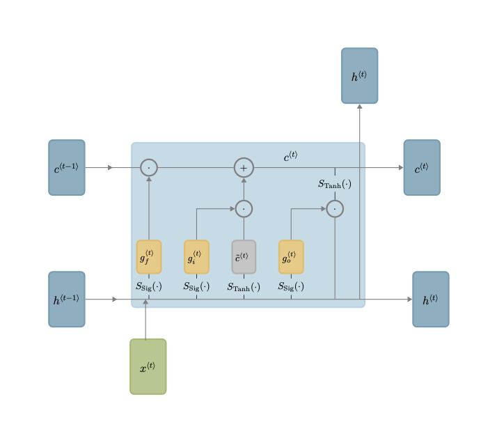

The **LSTM evolution equations** are,

$$\begin{equation}
\label{eq:lstm-full-model}
\left\{
\begin{aligned}
c^{<t>} & =g_f \odot c^{<t-1>} ~ +~ g_i \odot
\underbrace{S_{\text{Tanh}}\left(W_{\tilde{c}h} \, h^{<t-1>} +
W_{\tilde{c} x} \,
x^{<t>}+b_{\tilde{c}}\right)}_{\tilde{c}^{<t>}}
\quad \quad (\text{cell state}) \\
h^{<t>} &= g_o \odot S_{\text{Tanh}}( c^{<t>} )
\quad \quad\quad\quad\quad\quad\quad \quad\quad
\quad\quad\quad\quad\quad\quad \quad\quad\quad\quad\quad (\text{hidden
state}) \\[10pt]
\hat{y}^{<t>} &= S_y (W_{yh} h^{<t>} + b_y)
\end{aligned}\right.
\end{equation}$$

where for clarity we omit the time superscripts from the internal gates and denote them via $g_f$, $g_i$, and $g_o$. Importantly, at every time $t$ these internal gates are computed as,

$$\begin{equation}
\label{eq:lstm-full-model-part-2}
\left\{
\begin{aligned}
g_f &= S_{\text{Sig}} \big(W_{f h} h^{<t-1>} + W_{f
x}x^{<t>}+b_{f} \big)
\quad\quad (\text{forget gate})\\
g_i &= S_{\text{Sig}} \big(W_{ih} h^{<t-1>} + W_{ix}
x^{<t>} +b_i \big)
\quad\quad~~ (\text{input gate})\\
g_o &= S_{\text{Sig}} \big(W_{oh} h^{<t-1>)} + W_{ox}
x^{<t>} +b_o\big)
\quad\quad (\text{output gate})
\end{aligned}\right.
\end{equation}$$

- The internal gates help select which information is forgotten, used as input**, or used as output.
- At each time step $t$ the entries in the internal gate vectors $g_f^{<t>}$, $g_i^{<t>}$, and $g_o^{<t>}$ can be open, closed, or somewhere in-between where entries that are near $1$ are considered open and entries that are near $0$ are considered closed.
- The forget gate $g_f^{<t>}$ is multiplied element wise with the previous cell state $c^{<t-1>}$ to forget information from the previous cell state or not, depending on being closed or open respectively.
- Similarly, the input gate, $g_i^{<t>}$ controls what parts of the new cell content are written to the cell and this is applied to the internal cell state $\tilde{c}^{<t>}$ which models the selected information based on the current input and the previous short term memory.
- The output gate, $g_o^{<t>}$, controls what parts of the cell are written to the hidden state $h^{<t>}$ which is then used both for output $\hat{y}^{<t>}$ and the short term memory passed onto the next unit.

# Gated Recurrent Unit Models

- GRUs has a simpler architecture with only one key set of neurons $h^{<t>}$, again called the hidden state.
- Gated recurrent units store both long-term dependencies and short-term memory in the single hidden state.
- gated recurrent units use $[0,1]$ valued internal gates, this time called the reset gate $g_r^{<t>}$ and the update gate $g_u^{<t>}$.
- gated recurrent units provide a simpler architecture in comparison to LSTM as there are only two internal gates (in comparison to three) and a single group of states passed between time units (in comparison to two).

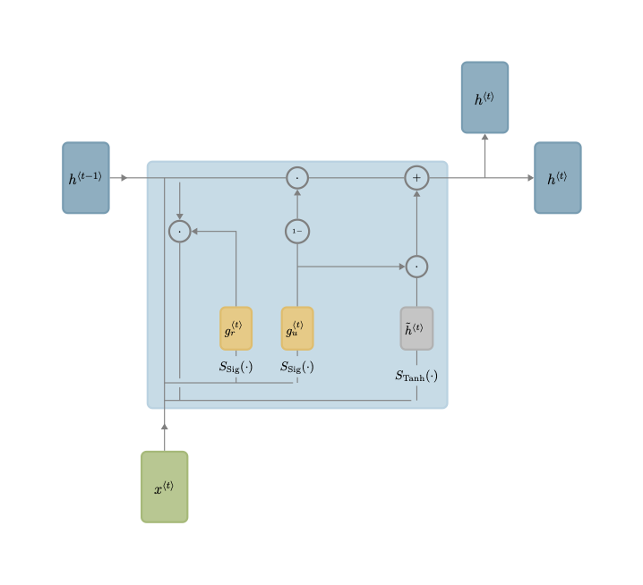

The basic evolution equation for gated recurrent units is,

$$\begin{equation}
\label{eq:gru-full-model}
\left\{
\begin{aligned}
h^{<t>} & =(1 - g_u) \odot h^{<t-1>} ~ +~ g_u \odot
\underbrace{S_{\text{Tanh}}\left(W_{\tilde{h}h} \, (g_r \odot
h^{<t-1>}) + W_{\tilde{h} x} \,
x^{<t>}+b_{\tilde{h}}\right)}_{\tilde{h}^{<t>}}, \\
\hat{y}^{<t>} &= S_y (W_{yh} h^{<t>} + b_y),
\end{aligned}\right.
\end{equation}$$

where for clarity we omit the time superscripts from the internal gates and denote them via $g_r$ and $g_u$. At every time $t$, these internal gates are computed as,
$$\begin{equation}
\label{eq:gru-full-model-part-2}
\left\{
\begin{aligned}
g_r &= S_{\text{Sig}} \big(W_{r h} h^{<t-1>} + W_{r
x}x^{<t>}+b_{r} \big),
\quad\quad ~~~ (\text{reset gate})\\
g_u &= S_{\text{Sig}} \big(W_{uh} h^{<t-1>} + W_{ux}
x^{<t>} +b_u \big).
\quad\quad~~~ (\text{update gate})\\
\end{aligned}\right.
\end{equation}$$

- Observe that the update gate $g_u$ plays a role similar to both the forget gate, $g_f$, and input gate, $g_i$ in LSTM.
- The simplification offered by GRU is to use a convex combination $(1-g_u, g_u)$ instead of a general linear combination $(g_f, g_i)$ as in LSTM.
- Observe that GRU’s internal hidden state $\tilde{h}^{<t>}$ is updated via a slightly more complex mechanism than LSTM’s internal cell state $\tilde{c}^{<t>}$.
- The innovation in GRUs is to use the reset gate, $g_r$. Practice has shown that with such an architecture, GRUs are able to maintain both long term and short term memory inside the hidden state sequence, $h^{<1>}, h^{<2>}, \ldots$.

# Encoders Decoders and the Attention Mechanism

Machine translation (MT) is one of the main active research area in Natural Language Processing (NLP).

- The **goal** is to provide a fast and reliable computer program that translates a text in one language (**source**) into another language (**the target**)

Using neural network model, the main architecture used for MT is the encoder–decoder model:

- encoder part which summarizes the information in the source sentence
- decoder part based on the encoding, generate the target-language output in a step-by-step fashion

## Encoder-Decoder Architectures for Machine Translation

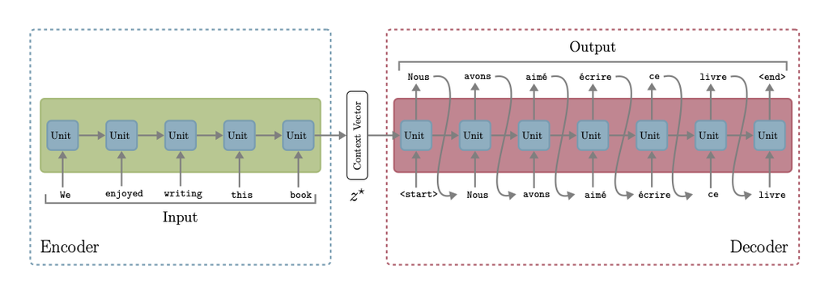

- In this model, the fixed length context vector $z^*$ encodes a variable-length sequence input.
- Then, the encoded is used as input of the decoder to produce a variable-length sequence token by token.
- The impact of context vector $z^*$ on the output will decrease as the output is predicted.

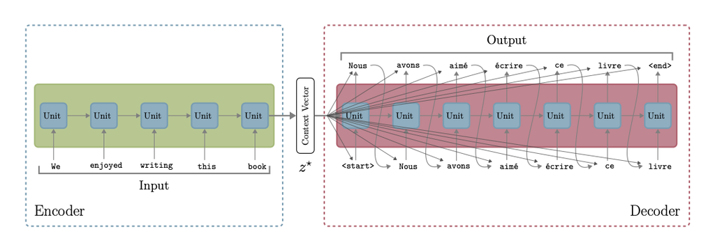

- A natural improvement of this architecture is to make the context vector accessible for **all steps** in the decoder part.
- The hidden cell (i.e. $h^{<t>}$) of the **decoder** is computed using the previous hidden cell (i.e. $h^{<t-1>}$), the previous output (i.e. $y^{<t-1>})$ and using the summary $c$.
- A **second improvement** is to also exploit the context vector $z^*$ for computing the probability of the next word:
  $$p(y^{<t>}|y^{<t-1>},\ldots,y^{<1>},z^*)=g(h^{<t-1>},y^{<t-1>},z^*).$$

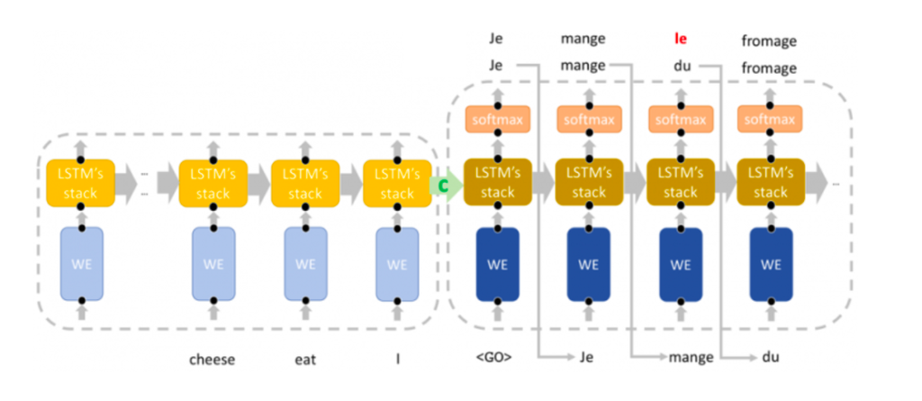

- A variant called **sequence-to-sequence learning** is a model exploited multilayered LSTM model for both encoder and decoder part.
- Deep LSTM is know to outperform shallow LSTM model.
- The encoder part reads the input sentence in reverse in order to introduce shorter dependencies between the source and the target sentence

## The Attention Mechanism

- An attention mechanism can be viewed as a transformation of a sequence of vectors to a sequence of vectors.
- The input sequence has $T_{\text{in}}$ vectors and the output sequence has $T_{\text{out}}$ vectors.
- We assume the vectors are $m$ dimensional and denote the input sequence via $v^{<1>}, v^{<2>},\ldots, v^{<T_{\text{in}}>}$ and the output sequence via $u^{<1>}, u^{<2>},\ldots, u^{<T_{\text{out}}>}$.
- As an aid to the attention mechanism, we also have two sequences of vectors, which we call here the proxy vectors .
- These are denoted via $z_k^{<1>}, z_k^{<2>},\ldots,z_k^{<T_{\text{in}}>}$, and $z_q^{<1>}, z_q^{<2>},\ldots, \ldots,z_q^{<T_{\text{out}}>}$, where each vector is $\tilde{m}$ dimensional.
- One of the components of the attention mechanism is a score function, $s: \Re^{\tilde{m}} \times \Re^{\tilde{m}} \to \Re$ which when applied to a pair of proxy vectors, $z_a$ and $z_b$ and denoted via $s(z_a, z_b)$, measures the similarity between the two proxy vectors.
- A typical simple score function is the inner product.
- For any time $t=1,\ldots,T_{\text{out}}$, we apply the score function on a fixed $z_q^{<t>}$ against all $z_k^{<1>}, z_k^{<2>},\ldots, \ldots,z_k^{<T_{\text{in}}>}$ and then using softmax we obtain a vector of attention weights of length $T_{\text{in}}$, denoted $\alpha^{<t>}$, and computed via

$$\begin{equation}
\label{eq:attention-weight-sofmax}
\alpha^{{\langle t \rangle}} = S_{\text{softmax}}\left(
\begin{bmatrix}
s(z_q^{{\langle t \rangle}}, z_k^{{\langle 1 \rangle}})\\
s(z_q^{{\langle t \rangle}}, z_k^{{\langle 2 \rangle}})\\
\vdots\\
s(z_q^{{\langle t \rangle}}, z_k^{{\langle T_{\text{in}} \rangle}})
\end{bmatrix}
\right),
\qquad
\text{for}
\qquad
t = 1,\ldots,T_{\text{out}}.
\end{equation}$$

- Thus in general, for any $t \in \{1,\ldots,T_{\text{out}}\}$, the attention weight vector $\alpha^{<t>}$ captures similarity between the proxy vector $z_q^{<t>}$ and all of the proxy vectors $z_k^{<1>},\ldots, \ldots,z_k^{<T_{\text{in}}>}$.
- With attention weights available, the attention mechanism operates on the input sequence $v^{<1>}, \ldots, v^{<T_{\text{in}}>}$. The mechanism produces an output sequence $u^{<1>}, \ldots, u^{<T_{\text{out}}>}$ where each $u^{<t>}$ is computed via the linear combination,

$$\begin{equation*}
\label{eq:attention-linear-comb}
\begin{cases}
u^{<t>} = \sum_{\tau = 1}^t\alpha^{<t>}_\tau
v^{<\tau>}, & (Causal\ attention) \\[10pt]
\qquad \qquad\qquad \text{or} & \\[10pt]
u^{<t>} = \sum_{\tau = 1}^{T_{\text{in}}} \alpha^{<t>}_\tau
v^{<\tau>},
& (Non-causal\ attention).
\end{cases}
\end{equation*}$$

- In the casual form, the output at time $t$, $u^{<t>}$, only depends on the inputs up to time $t$
- In non casual form $u^{<t>}$ depends on inputs at all times $t \in \{1,\ldots,T_{\text{in}}\}$.

## Encoder Decoder with An Attention Mechanism

[Bahdanau et al. (2015)](https://arxiv.org/abs/1409.0473) have proposed to include **attention layer** which consist to include attention mechanisms to give more importance to some of the input words compared to others while translating the sentence.

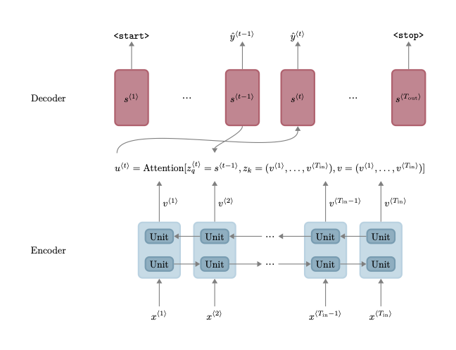

$$\begin{align*}
s^{<t>} &= f_{\text{decoder}}\big(s^{<t-1>},
\hat{y}^{<t-1>}, u^{<t>} \big), \\
\hat{y}^{<t>} &= f_{\text{decoder-out}}\big(s^{<t>}
\big).
\end{align*}$$

## Illustration of weight attention

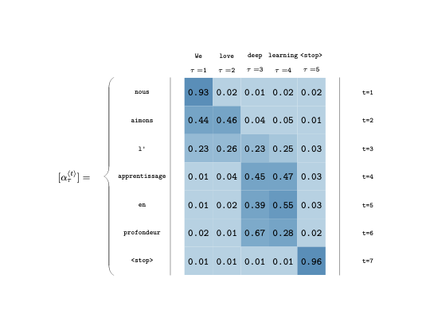

- This matrix shows how the attention weights adjusts its focus according to context.
- For the first output the attention mechanism focus principally on the word we (93%) and then the encoder provides nous as output.
- For the second output the attention weight gives similar importance to we and love and then offer aimons and so on
- One can also exploit more complex score function such for example:
  $$\textrm{score}(s^{<t-1>},h^{<j>})=\left\{
  \begin{array}{ll}
  (s^{<t-1>})^\top W_a h^{<j>}
  &\textrm{``general''}\\
  v_a^\top \textrm{tanh}(W_a [s^{<t-1>}, h^{<j>}]) &
  \textrm{``concat''}\\
  v_a^\top \textrm{tanh}(W_a s^{<t-1>}+U_a h^{<j>}) &
  \textrm{``additive''}\\
  \end{array}
  \right.,$$
  where $v_a$, $W_a$, $U_a$ are weight parameter which are trained during the learning phase.
- A survey of the different implementations of attention model is presented by [Galassi et al. (2019)](https://arxiv.org/abs/1902.02181)

# Transformers Model

**Transformer model** has been viewed as a kind of revolution for machine translation (MT).

- This model exploits different variation of attention mechanisms without any recurrent layers.
- Thus without any recurrent connexion some computation with the transformer model can be parallelise.
- The transfomer architecture has inherited the Encoder-Decoder pattern. Each part is build up of stack transformer blocks which are blocs combining feedforward networks and self-attention layers.
- [Attention is all you need (2017)](https://proceedings.neurips.cc/paper/2017/file/3f5ee243547dee91fbd053c1c4a845aa-Paper.pdf).

## Self Attention

- With transformer architecture, the proxy vectors $z_q^{{\langle t \rangle}}$ as queries, and $z_k^{{\langle t \rangle}}$ as keys, and the input vectors $v^{{\langle t \rangle}}$ as values.
- Terminology from **information retrieval systems**. Captures the fact that when we compute an attention vector $\alpha^{{\langle t \rangle}}$, we are **searching** for a query represented via $z_q^{{\langle t \rangle}}$ against all keys $z_k^{{\langle 1 \rangle}}, \ldots, z_k^{{\langle T_{\text{in}} \rangle}}$. Then the attention weights are used to combine the **search results**.
- We set the queries, the keys, and the values directly as the input.
  $$z_q^{{\langle t \rangle}} = x^{{\langle t \rangle}},
  \qquad
  z_k^{{\langle t \rangle}} = x^{{\langle t \rangle}},
  \qquad
  v^{{\langle t \rangle}} = x^{{\langle t \rangle}},$$
  and this implies that in **the casual form**, with score function $s(\cdot, \cdot)$, the self attention mechanism yields output for any time $t \in \{1,\ldots,T\}$, via,

$$\begin{equation*}
\label{eq:simple-casual-self-attention}
u^{{\langle t \rangle}}=\sum_{\tau \le t} \alpha^{{\langle t
\rangle}}_\tau \,x^{{\langle \tau \rangle}},
\qquad
\textrm{with}
\qquad
\alpha_{\tau}^{{\langle t \rangle}} = \frac{e^{s(x^{{\langle t
\rangle}},x^{{\langle \tau \rangle}})}}{\sum_{t'=1}^t
e^{s(x^{{\langle t \rangle}},x^{{\langle t' \rangle}})}}.
\end{equation*}$$

### Versatile Self Attention

- A more versatile form of self attention has queries, keys, and values that are not directly taken as the input, but are rather **linear transformations of the input**.

$$z_q^{{\langle t \rangle}} = W_q x^{{\langle t \rangle}},
\qquad
z_k^{{\langle t \rangle}} = W_k x^{{\langle t \rangle}},
\qquad
v^{{\langle t \rangle}} = W_v x^{{\langle t \rangle}},$$

where the **learnable parameter matrices** $W_q$, $W_k$, and $W_v$ are each $p \times p$ dimensional.

- The attention mechanism has output for any time $t \in \{1,\ldots,T\}$, via,

$$\begin{equation*}
\label{eq:more-versatile-casual-self-attention}
u^{{\langle t \rangle}}=\sum_{\tau \le t} \alpha^{{\langle t
\rangle}}_\tau \,W_v \, x^{{\langle \tau \rangle}},
\qquad
\textrm{with}
\qquad
\alpha_{\tau}^{{\langle t \rangle}} = \frac{e^{s(W_q \,x^{{\langle t
\rangle}}, W_k \,x^{{\langle \tau \rangle}})}}{\sum_{t'=1}^t
e^{s(W_q \,x^{{\langle t \rangle}},W_k \,x^{{\langle t'
\rangle}})}}.
\end{equation*}$$

## Multi-Head Self Attention

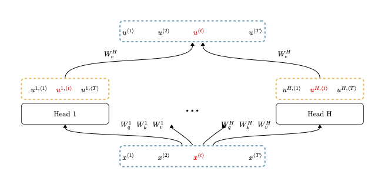

$$\begin{equation*}
\label{eq:one-head-mha}
u^{h,{\langle t \rangle}}=\sum_{\tau =1}^{T} \alpha^{h,{\langle t
\rangle}}_\tau \, W_v^h \, x^{{\langle \tau \rangle}},
\qquad
\textrm{with}
\qquad
\alpha_{\tau}^{h,{\langle t \rangle}} = \frac{e^{s(W_q^h \,x^{{\langle t
\rangle}}, W_k^h \,x^{{\langle \tau \rangle}})}}{\sum_{t'=1}^t
e^{s(W_q^h \,x^{{\langle t \rangle}}, W_k^h \,x^{{\langle t'
\rangle}})}}.
\end{equation*}$$

## Positional Embeddings

- Sequence models have a **natural time index**, $t$, where $x^{{\langle t \rangle}}$ followed by $x^{{\langle t+1 \rangle}}$, embodies some relationship between the two vectors in the sequence.
- deep learning, and the reverse text, learning deephave different semantic meaning, since the order matters.
- With multi-head self attention mechanism the order in the input sequence $x^{{\langle 1 \rangle}},\ldots,x^{{\langle T \rangle}}$ **is not captured** by the mechanism at all.
- A basic and primitive form of positional embedding is to extend each input vector $x^{{\langle t \rangle}}$ with an additional one hot encoded vector that captures its position in the sequence.
- For example for a sequence of length $T=4$, we extend $x^{{\langle 1 \rangle}}$ with $e_1 = (1,0,0,0)$, extend $x^{{\langle 2 \rangle}}$ with $e_2 = (0,1,0,0)$, and so fourth.
- Example with $p=2$ and $T=4$, assume the first vector is $x^{{\langle 1 \rangle}} = (0.2,-1.3)$ and assume that as a matter of coincidence the last vector $x^{{\langle 4 \rangle}}$ has the same values. Then after applying such positional embedding, the vectors are transformed to

$$\tilde{x}^{{\langle 1 \rangle}} = (0.2,-1.3, \underbrace{1, 0, 0,
0}_{e_1})
\qquad
\text{and}
\qquad
\tilde{x}^{{\langle 4 \rangle}} = (0.2,-1.3, \underbrace{0, 0, 0,
1}_{e_4}),$$

then the model can distinguish between $\tilde{x}^{{\langle 1 \rangle}}$ and $\tilde{x}^{{\langle 4 \rangle}}$.

## Transformer block

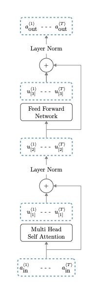

- Two main layers being a multi-head self attention layer, and downstream to it, a feedforward layer.
- Each of these also utilizes a residual connection and a normalization layer.
- The residual connections enhance training performance, similar to ResNets.
- Normalization, in the form of layer normalization, stabilizes training and production performance (values remain in a sensible dynamic range).
- Input of a transformer block as $a_{\text{in}}$ and the output as $a_{\text{out}}$ where both $a_{\text{in}}$ and $a_{\text{out}}$ are $p \times T$ matrices.
- The block view as a function $f_{\theta}: \mathbb{R}^{p \times T} \rightarrow \mathbb{R}^{p \times T}$, where $\theta$ represents trained parameters of the block and $a_{\text{out}} = f_{\theta}(a_{\text{in}})$.
- For example, the encoder of the transformer architecture has a first transformer block that operates on input,

$$a_{\text{in}} = \big[\tilde{x}^{{\langle 1
\rangle}},\ldots,\tilde{x}^{{\langle T \rangle}}\big],$$

where each column is a positional encoding vector. Then the output of this block, $a_{\text{out}}$, is fed into a second transformer block in the encoder, and so fourth.

## Number of parameter

- Learned parameters of a single transformer block with dimensions $p$ for the vector length, $T$ for the sequence length, $H$ for the number of self-attention heads, $m_v$ for the length of the values inside each self-attention block, and $m$ for the dimension of the query and key inside each self-attention block.

$$\begin{equation*}
\label{eq:transformer-parameters-counts}
\underbrace{4\, p}_{\gamma, \beta, \tilde{\gamma}, \tilde{\beta}} +
\underbrace{2\,N_1 p}_{W^{[1]}, W^{[2]} } + \underbrace{N_1 +
p}_{b^{[1]}, b^{[2]}} +~~ H \times
(\underbrace{2\,m\,p}_{W_k^{h}~\text{and}~W_q^{h}} +
\underbrace{2\,m_v\, p}_{W_v^{h}~\text{and}~W_c^{h}}).
\end{equation*}$$

- Let us consider a case with $p=512$, $N_1 = 2048$, $m = m_v = 64$, and $H=8$:
- In this case there are just over 3 million learnable parameters for such a transformer block.

## Transformer decoder block

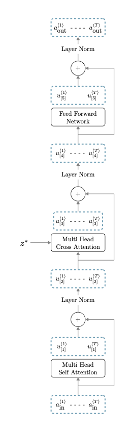

- The multi-head self attention layer is causal. This is implemented via masking mechanism.
- Such causality prevents attendance of future positions as suitable for autoregressive prediction.
- An additional layer, called a cross attention layer, is used between the causal multi-head self attention and the feedforward layer.
- The cross attention layer is fed with the encoder output $z_*$.
- The cross attention layer allows the transformer decoder block to directly incorporate the encoder’s code.
- Transformer decoders are constructed by stacking several transformer decoder blocks in sequence, similarly to the stacking in the encoder, where each block gets the same$z_*$.
- On top of the final transformer decoder block, we add an additional layer transforming each output vector to a token.
- Often it is simply a linear layer with a softmax (i.e. a multinomial regression).

## Number of Parameter

- The parameters of each transformer decoder block include those of the transformer block as well as parameters resulting from the multi-head cross attention layer and its normalization.
- For the decoder, the parameter count needs to be augmented with an additional $H \times (2mp + 2m_vp)$ term for the multi-head cross attention as well as $2p$ for the additional normalization parameters.
- As an example, using the same dimensions as above, we now have over $4$ million parameters, or 4,199,936 exactly, for the whole transformer decoder block.

## Transformer architecture

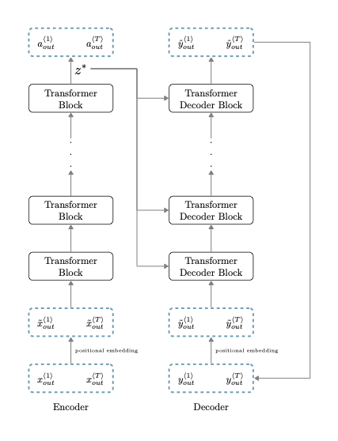

## Number of parameters

- An encoder decoder transformer architecture with $6$ transformer blocks in the encoder and $6$ transformer decoder blocks in the decoder: 19 million for the encoder} and 25 million for the decoder
- Require an additional layer on top of the decoder, transforming each output vector to a token.
- Use a linear layer with a softmax (i.e. a multinomial regression). This type of layer is needed at the end of any pipeline that generates text.
- If we assume that the number of word tokens is $d_{\cal{V}} \approx 37,000$, then the number of parameters of the final multinomial regression is $d_{\cal{V}}\times p + p$, which is about $19$ million parameters in our case.
- Hence putting the pieces together we have about $63$ million parameters in the whole model.

## Using the Encoder-Decoder in Production and Training

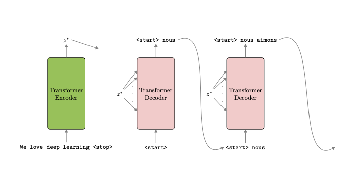

- In production: decoder is used in auto-regressive manner:
  $$\hat{y}^{{\langle t \rangle}} =
  f_{\text{decoder}}\big({z}_*, (\tilde{y}^{{\langle 1
  \rangle}},\ldots,\tilde{y}^{{\langle t-1 \rangle}}) \big),$$
- In training: decoder uses teacher forcing techniques (use the actual label in place the generated probability)

## Large language models: model size

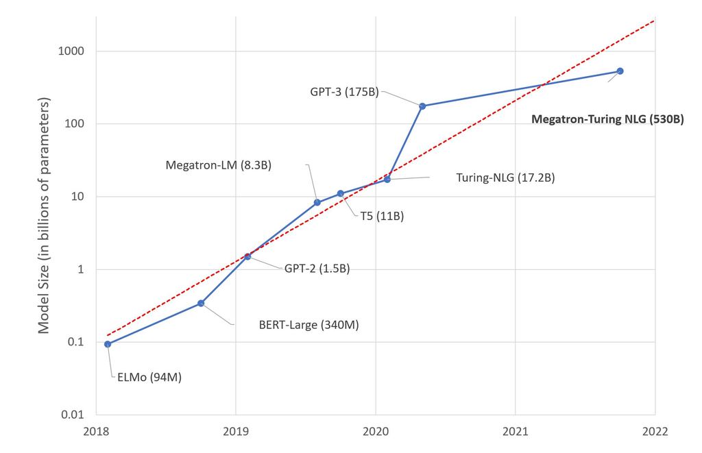

- figure from https://www.microsoft.com/en-us/research/blog/using-deepspeed-and-megatron-to-train-megatron-turing-nlg-530b-the-worlds-largest-and-most-powerful-generative-language-model/

### Further reading for MT

- Understand [attention concept](https://lilianweng.github.io/lil-log/2018/06/24/attention-attention.html)
- Understand [attention interface](https://distill.pub/2016/augmented-rnns/#attentional-interfaces)
- A comprehensive illustration of the [transformer](http://jalammar.github.io/illustrated-transformer/)
- [Chen et al. (2018)](https://www.aclweb.org/anthology/P18-1008.pdf) who compared several types of recent MT models
- A comprehensive PyTorch-based seq2seq tutorial by Joost Bastings:[The Annotated Encoder–Decoder with Attention](https://bastings.github.io/annotated_encoder_decoder/)

## Time to some short practices

- [Python: tutorial 1, time series](https://colab.research.google.com/drive/1wWjPT8yBuuofvwKJgl8bIlhMsWV9Z0dk?usp=sharing)
- [Python: tutorial 2, IMBd data](https://colab.research.google.com/drive/1R_T_klRPjp0x2k715zVcxGbXBPbGz9cx?usp=sharing)
- R: tutorial 1, time series
- R: tutorial 2, IMBd data
- R: tutorial 3, word embeddings

## Tutorial Resources

- [R code](https://github.com/fmmattioni/deep-learning-with-r-notebooks)
- [Python code](https://github.com/fchollet/deep-learning-with-python-notebooks)